# Machine Learning - Personal Loan Campaign

#### Decision Tree 3 - Post pruning

```python
tree_0 = DecisionTreeClassifier(random_state=1)
post_pruning_path = tree_0.cost_complexity_pruning_path(X_train, y_train)
ccp_alphas, impurities = post_pruning_path.ccp_alphas, post_pruning_path.impurities
```

```python
post_pruned_trees = []

#For each alpha value prune the tree and store in a list
for value in ccp_alphas:
    tree = DecisionTreeClassifier(random_state = 1, ccp_alpha=value)
    tree.fit(X_train, y_train)
    post_pruned_trees.append(tree)


#Evaluate the pruned trees
recall_train = []
recall_test = []

for value in post_pruned_trees:
    y_pred_train = value.predict(X_train)
    values_train = recall_score(y_train, y_pred_train)
    recall_train.append(values_train)

for value in post_pruned_trees:
    y_pred_test = value.predict(X_test)
    values_test = recall_score(y_test,y_pred_test)
    recall_test.append(values_test)


#Accuracy of train and test scores
train_scores = [value.score(X_train, y_train) for value in post_pruned_trees]
test_scores = [value.score(X_test, y_test) for value in post_pruned_trees]

index_best_model = np.argmax(recall_test)
best_model = post_pruned_trees[index_best_model]
print("Best model is : ",index_best_model)
print("Recall value giving best pred model is : ",recall_test[index_best_model])
print("Best alpha value is : ",ccp_alphas[index_best_model])
```

```
Best model is :  21
Recall value giving best pred model is :  0.9027777777777778
Best alpha value is :  0.0009377289377289376
```

```python
model3 = best_model
```

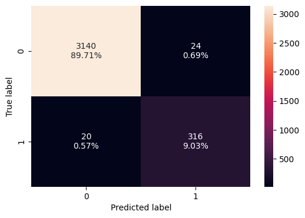

```python
confusion_matrix_dt(model3, X_train, y_train)
```

```python
dt3_train = model_performance_dt(model3, X_train, y_train)
dt3_train
```

|  | Accuracy | Recall | Precision | F1 |
| --- | --- | --- | --- | --- |
| 0 | 0.987429 | 0.940476 | 0.929412 | 0.934911 |

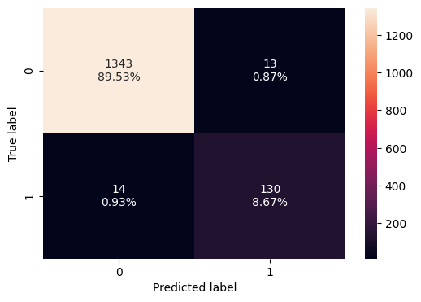

```python
confusion_matrix_dt(model3, X_test, y_test)
```

```python
dt3_test = model_performance_dt(model3, X_test, y_test)
dt3_test
```

|  | Accuracy | Recall | Precision | F1 |
| --- | --- | --- | --- | --- |
| 0 | 0.982 | 0.902778 | 0.909091 | 0.905923 |

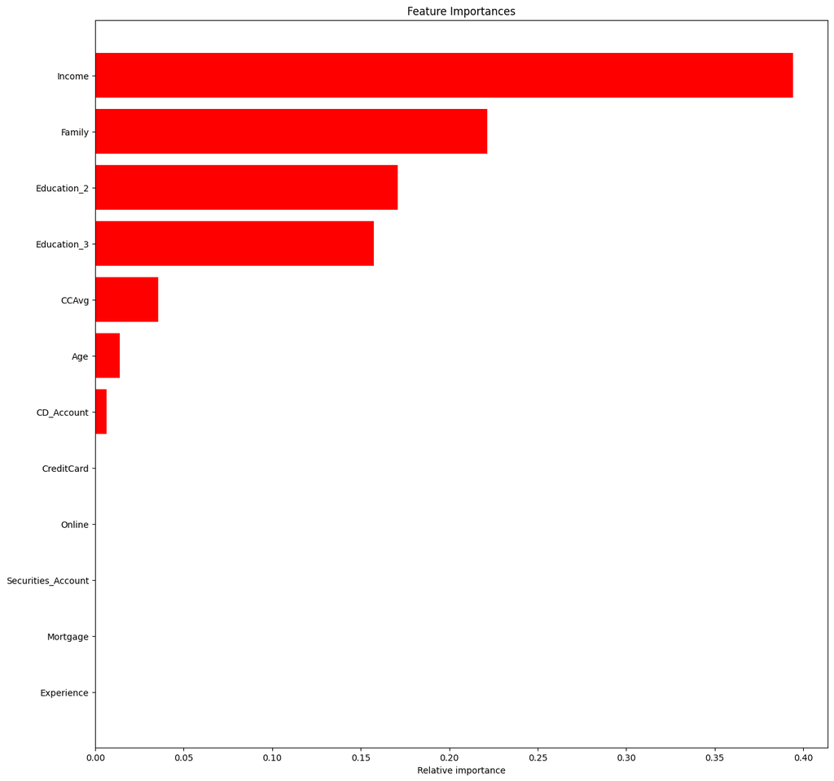

```python
feature_imp_plot(model3,X_train)
```

```python
## Training performance comparison

models_train = pd.concat([dt1_train.T,dt2_train.T,dt3_train.T], axis =1)
models_train.columns = ["Default", "Pre pruning", "Post pruning"]

print(models_train)
```

```
           Default  Pre pruning  Post pruning
Accuracy       1.0     0.990571      0.987429
Recall         1.0     0.934524      0.940476
Precision      1.0     0.966154      0.929412
F1             1.0     0.950076      0.934911
```

```python
## Testing performance comparison

models_test = pd.concat([dt1_test.T,dt2_test.T,dt3_test.T], axis =1)
models_test.columns = ["Default", "Pre pruning", "Post pruning"]

print(models_test)
```

```
            Default  Pre pruning  Post pruning
Accuracy   0.980000     0.981333      0.982000
Recall     0.868056     0.861111      0.902778
Precision  0.919118     0.939394      0.909091
F1         0.892857     0.898551      0.905923
```

### Observations and Buisiness Recommendations

1. The best performing model was derived from Decision Tree Modelling with post pruned tree where Recall values are a lot similar.
2. The customer attributes more significant are :

   a. Income - Higher the Income, more chances the customer will accept a personal loan. b. Family - As familly size grows, customers are more willing to accept personal loan c. Education_2 - Customers with Education level 2 are more willing to accept a personal loan than levels 1 & 3 d. Education_3 - Customers with Education level are more willing to accept a personal loan than level 1 e. CCAvg - As the monthly spending of customers increase, the more they are willing to accept personal loan
3. Focus more on customers who fall into the categories as mentioned above.
4. Bank can focus on improving campaigns for Online users as they are very much less.
5. Can focus more on existing cutomers like the ones with Securities accound and CD account by giving them special discounts compared to searching for new customers.
6. Improve customer services and offers for varied age group people.
7. Simplify the loan procedures to ease the process.